# Lab 4

2024-10-08

# Import libraries

```r
library(here)
library(lubridate)
library(readxl)
library(janitor)
library(tidyverse)
library(sf)
electricity_district <- read_csv("studentData/electricity_district.csv")
head(electricity_district)
```

```
## # A tibble: 6 × 10
##   datetime            AREA18 AREA20 AREA27 AREA29 AREA36 AREA40 AREA47 AREA54
##   <dttm>               <dbl>  <dbl>  <dbl>  <dbl>  <dbl>  <dbl>  <dbl>  <dbl>
## 1 2011-01-01 00:00:00   18.8   258.   65.4   109.   27.0   145.   82.8   113.
## 2 2011-01-01 01:00:00   18.1   254.   63.4   109.   26.5   140.   81.9   108.
## 3 2011-01-01 02:00:00   17.5   251.   61.8   111.   26.4   136.   81.2   104.
## 4 2011-01-01 03:00:00   17.1   247.   60.9   108.   27.0   132.   80.4   102.
## 5 2011-01-01 04:00:00   16.8   245.   61.1   108.   27.3   130.   80.4   101.
## 6 2011-01-01 05:00:00   16.7   244.   61.9   107.   25.5   129.   80.0   103.
## # ℹ 1 more variable: AREA56 <dbl>
```

```r
dictionary <- read_csv("studentData/dictionary.csv")
head(dictionary)
```

```
## # A tibble: 6 × 2
##   name                     code
##   <chr>                   <dbl>
## 1 Brooks                     43
## 2 Brooks                     93
## 3 Brooks                    272
## 4 Brooks                     17
## 5 Brooks                    235
## 6 Alliance / Battle River    16
```

# Exploring the data

```r
dictionary |>
  filter (name == "Hinton / Edson")
```

```
## # A tibble: 5 × 2
##   name            code
##   <chr>          <dbl>
## 1 Hinton / Edson   151
## 2 Hinton / Edson   100
## 3 Hinton / Edson   482
## 4 Hinton / Edson   167
## 5 Hinton / Edson   418
```

```r
population <- read_csv("studentData/population.csv")
head(population)
```

```
## # A tibble: 6 × 3
##    year  code population
##   <dbl> <dbl>      <dbl>
## 1  2011     3      43155
## 2  2011    43      13581
## 3  2011    46    1090936
## 4  2011    48      17236
## 5  2011   525      13924
## 6  2011    98     782439
```

# Plotting using shape files

```r
planning_areas <- st_read("studentData/shape/AESO_Planning_Areas.shp") |>
  mutate(Area_ID = as.numeric(Area_ID))
head(planning_areas)
```

```
## Simple feature collection with 6 features and 3 fields
## Geometry type: POLYGON
## Dimension:     XY
## Bounding box:  xmin: -116.379 ymin: 49.36193 xmax: -110.0015 ymax: 55.42177
## Geodetic CRS:  NAD83
##           NAME  REGION Area_ID                       geometry
## 1     Vauxhall   South      52 POLYGON ((-112.6214 49.9681...
## 2 Lloydminster Central      13 POLYGON ((-111.1471 53.8064...
## 3     Caroline Central      38 POLYGON ((-115.4357 52.5768...
## 4        Seebe   South      44 POLYGON ((-116.379 51.48562...
## 5    Cold Lake Central      28 POLYGON ((-112.4013 54.1426...
## 6   Lethbridge   South      54 POLYGON ((-113.2958 49.9648...
```

Let’s build a basic map to understand the capabilities of a shape file.

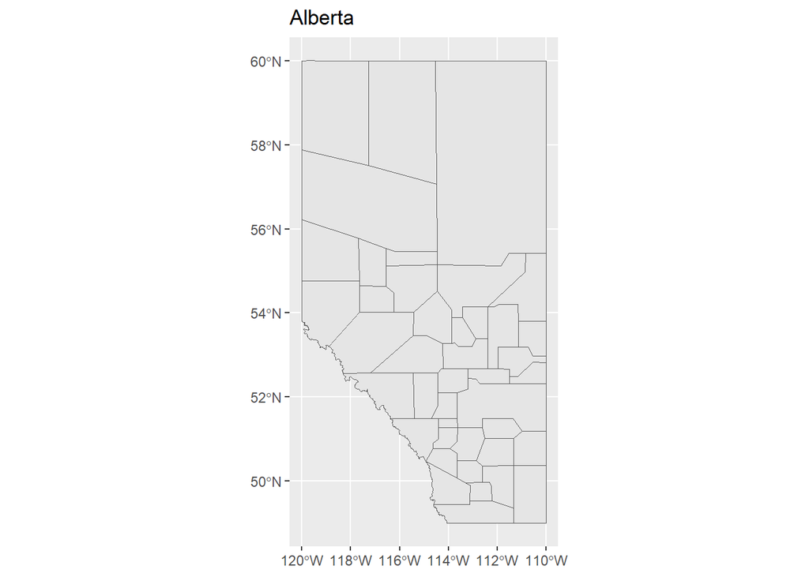

```r
# Basic plot
base_map <- ggplot(planning_areas) +
  geom_sf() +
  labs(title = "Alberta")
base_map
```

Perfect! Now we want to fill this map with data. For the moment, we only care about 9 districts given in the dataset “districts_included.csv”.

```r
districts_included <- read.csv("studentData/districts_included.csv")
districts_included
```

```
##                       NAME Area_ID
## 1               Lethbridge      54
## 2 Athabasca / Lac La Biche      27
## 3               Vegreville      56
## 4               High Level      18
## 5  Alliance / Battle River      36
## 6                   Brooks      47
## 7           Grande Prairie      20
## 8                  Wabamun      40
## 9           Hinton / Edson      29
```

In order to plot those 9 district, the first approach is to conduct an inner join, assuming we don’t care about the rest of the districts.

```r
planning_areas_trial <- planning_areas %>%
  inner_join(districts_included, by = "Area_ID")
head(planning_areas_trial)
```

```
## Simple feature collection with 6 features and 4 fields
## Geometry type: POLYGON
## Dimension:     XY
## Bounding box:  xmin: -117.2804 ymin: 49.52929 xmax: -110.8485 ymax: 60.00202
## Geodetic CRS:  NAD83
##                     NAME.x    REGION Area_ID                   NAME.y
## 1               Lethbridge     South      54               Lethbridge
## 2 Athabasca / Lac La Biche Northeast      27 Athabasca / Lac La Biche
## 3               Vegreville   Central      56               Vegreville
## 4               High Level Northwest      18               High Level
## 5  Alliance / Battle River   Central      36  Alliance / Battle River
## 6                   Brooks     South      47                   Brooks
##                         geometry
## 1 POLYGON ((-113.2958 49.9648...
## 2 POLYGON ((-114.4495 55.1444...
## 3 POLYGON ((-112.4013 54.1426...
## 4 POLYGON ((-117.2804 59.9999...
## 5 POLYGON ((-113.2049 52.6772...
## 6 POLYGON ((-112.5164 51.0141...
```

Let’s plot this new data frame (the output of our inner join).

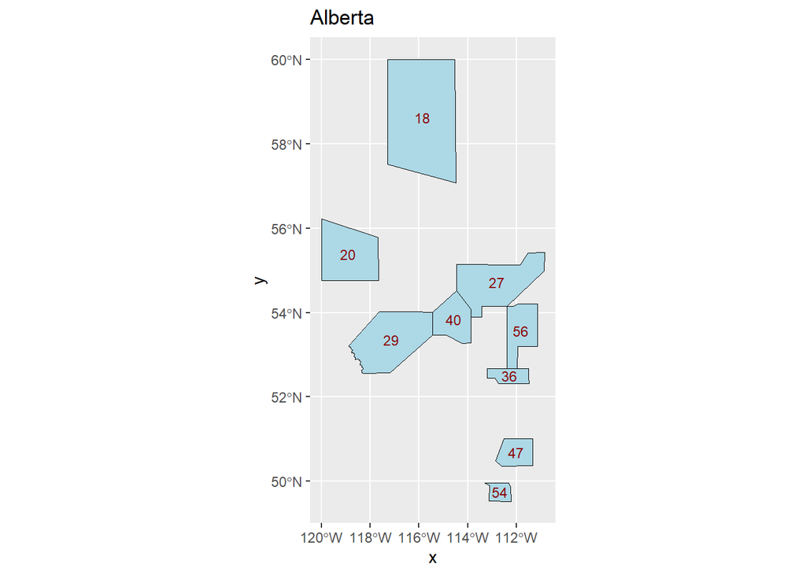

```r
alberta <- ggplot(planning_areas_trial) +
  geom_sf(fill = "lightblue", color = "black") +
  geom_sf_text(data = st_centroid(planning_areas_trial),
               aes(label = Area_ID),
               color = "darkred", size = 3) +
  labs(title = "Alberta")
alberta
```

This map, while focusing on just our problem at hand, is not a complete solution as it does not show the entire map. This output is not desirable. Let’s make some small changes in the data to obtain the full picture.

```r
planning_areas <- planning_areas %>%
  left_join(districts_included, by = "Area_ID")
head(planning_areas)
```

```
## Simple feature collection with 6 features and 4 fields
## Geometry type: POLYGON
## Dimension:     XY
## Bounding box:  xmin: -116.379 ymin: 49.36193 xmax: -110.0015 ymax: 55.42177
## Geodetic CRS:  NAD83
##         NAME.x  REGION Area_ID     NAME.y                       geometry
## 1     Vauxhall   South      52       <NA> POLYGON ((-112.6214 49.9681...
## 2 Lloydminster Central      13       <NA> POLYGON ((-111.1471 53.8064...
## 3     Caroline Central      38       <NA> POLYGON ((-115.4357 52.5768...
## 4        Seebe   South      44       <NA> POLYGON ((-116.379 51.48562...
## 5    Cold Lake Central      28       <NA> POLYGON ((-112.4013 54.1426...
## 6   Lethbridge   South      54 Lethbridge POLYGON ((-113.2958 49.9648...
```

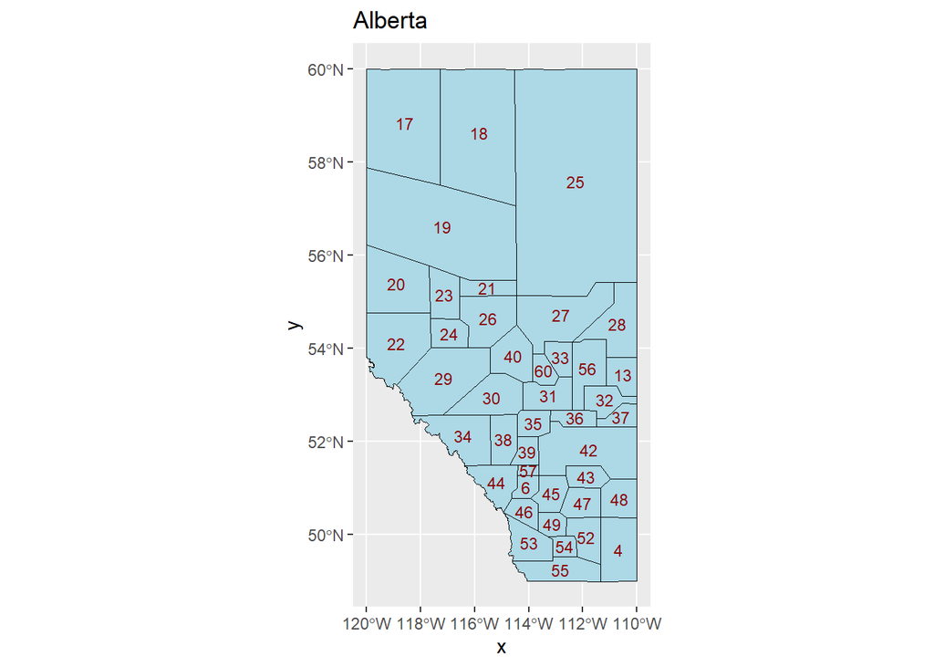

```r
alberta_complete <- ggplot(planning_areas) +
  geom_sf(fill = "lightblue", color = "black") +
  geom_sf_text(data = st_centroid(planning_areas),
               aes(label = Area_ID),
               color = "darkred", size = 3) +
  labs(title = "Alberta")
alberta_complete
```

Out of this, we only want to label the 9 districts :

| **Name** | **Area_ID** |
| --- | --- |
| Lethbridge | 54 |
| Athabasca / Lac La Biche | 27 |
| Vegreville | 56 |
| High Level | 18 |
| Alliance / Battle River | 36 |
| Brooks | 47 |
| Grande Prairie | 20 |
| Wabamun | 40 |
| Hinton / Edson | 29 |

So, we will create a new column in “planning_areas” called id_label that returns the Area_ID if the Area_ID is included in the 9 districts and NA if it is not.

One idea to do this is to create the id_label column in “districts_included” and then left join it to planning areas.

```r
districts_included <- districts_included |>
  mutate(id_label = Area_ID) |>
  select(Area_ID, id_label)
districts_included
```

```
##   Area_ID id_label
## 1      54       54
## 2      27       27
## 3      56       56
## 4      18       18
## 5      36       36
## 6      47       47
## 7      20       20
## 8      40       40
## 9      29       29
```

```r
planning_areas_joined <- planning_areas |>
  left_join(districts_included, by = "Area_ID") |>
  mutate(id_label = as.character(id_label)) |>
  mutate(id_label = ifelse(is.na(id_label), "", id_label))
head(planning_areas_joined)
```

```
## Simple feature collection with 6 features and 5 fields
## Geometry type: POLYGON
## Dimension:     XY
## Bounding box:  xmin: -116.379 ymin: 49.36193 xmax: -110.0015 ymax: 55.42177
## Geodetic CRS:  NAD83
##         NAME.x  REGION Area_ID     NAME.y id_label
## 1     Vauxhall   South      52       <NA>
## 2 Lloydminster Central      13       <NA>
## 3     Caroline Central      38       <NA>
## 4        Seebe   South      44       <NA>
## 5    Cold Lake Central      28       <NA>
## 6   Lethbridge   South      54 Lethbridge       54
##                         geometry
## 1 POLYGON ((-112.6214 49.9681...
## 2 POLYGON ((-111.1471 53.8064...
## 3 POLYGON ((-115.4357 52.5768...
## 4 POLYGON ((-116.379 51.48562...
## 5 POLYGON ((-112.4013 54.1426...
## 6 POLYGON ((-113.2958 49.9648...
```

Now, as you can see, id_label has empty rows for the districts we aren’t concerned about. Let’s plot this data frame with id_label as the labels.

```r
st_centroid(planning_areas_joined)
```

```
## Simple feature collection with 42 features and 5 fields
## Geometry type: POINT
## Dimension:     XY
## Bounding box:  xmin: -118.8996 ymin: 49.24711 xmax: -110.534 ymax: 58.83714
## Geodetic CRS:  NAD83
## First 10 features:
##                      NAME.x    REGION Area_ID                   NAME.y id_label
## 1                  Vauxhall     South      52                     <NA>
## 2              Lloydminster   Central      13                     <NA>
## 3                  Caroline   Central      38                     <NA>
## 4                     Seebe     South      44                     <NA>
## 5                 Cold Lake   Central      28                     <NA>
## 6                Lethbridge     South      54               Lethbridge       54
## 7                 Sheerness     South      43                     <NA>
## 8                Wainwright   Central      32                     <NA>
## 9                   Calgary   Calgary       6                     <NA>
## 10 Athabasca / Lac La Biche Northeast      27 Athabasca / Lac La Biche       27
##                      geometry
## 1  POINT (-111.8734 49.94678)
## 2   POINT (-110.534 53.43168)
## 3  POINT (-114.9385 52.05564)
## 4   POINT (-115.2027 51.1252)
## 5  POINT (-110.7289 54.53234)
## 6  POINT (-112.6844 49.74942)
## 7  POINT (-111.8724 51.25069)
## 8  POINT (-111.1934 52.89495)
## 9   POINT (-114.091 51.02301)
## 10 POINT (-112.8188 54.72178)
```

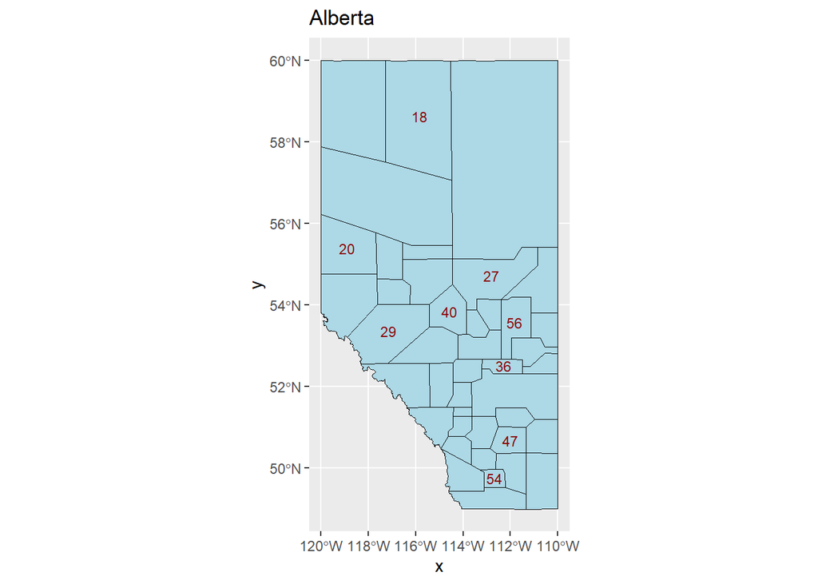

```r
alberta_9_dist <- ggplot(planning_areas_joined) +
  geom_sf(fill = "lightblue", color = "black") +
  geom_sf_text(data = st_centroid(planning_areas_joined),
               aes(label = id_label),
               color = "darkred", size = 3) +
  labs(title = "Alberta ")
alberta_9_dist
```

We have finally created a desirable chart. Let’s attempt some visualizations.

Problem statement: Visualize the relative energy consumption in the 9 districts.

For this, we need the population of the 9 districts, their respective energy consumption and consumption per individual (compare apples to apples).

```r
electricity_district <- electricity_district |>
  rename("18" = AREA18,
         "20" = AREA20,
         "27" = AREA27,
         "29" = AREA29,
         "36" = AREA36,
         "40" = AREA40,
         "47" = AREA47,
         "54" = AREA54,
         "56" = AREA56)
head(electricity_district)
```

```
## # A tibble: 6 × 10
##   datetime             `18`  `20`  `27`  `29`  `36`  `40`  `47`  `54`  `56`
##   <dttm>              <dbl> <dbl> <dbl> <dbl> <dbl> <dbl> <dbl> <dbl> <dbl>
## 1 2011-01-01 00:00:00  18.8  258.  65.4  109.  27.0  145.  82.8  113.  58.0
## 2 2011-01-01 01:00:00  18.1  254.  63.4  109.  26.5  140.  81.9  108.  56.1
## 3 2011-01-01 02:00:00  17.5  251.  61.8  111.  26.4  136.  81.2  104.  55.1
## 4 2011-01-01 03:00:00  17.1  247.  60.9  108.  27.0  132.  80.4  102.  55.1
## 5 2011-01-01 04:00:00  16.8  245.  61.1  108.  27.3  130.  80.4  101.  54.7
## 6 2011-01-01 05:00:00  16.7  244.  61.9  107.  25.5  129.  80.0  103.  53.8
```

```r
electricity_long <- electricity_district %>%
  pivot_longer(cols = c("18","20","27","29","36","40","47","54","56"),
               names_to = "Area_ID",
               values_to = "electricity_use")
head(electricity_long)
```

```
## # A tibble: 6 × 3
##   datetime            Area_ID electricity_use
##   <dttm>              <chr>             <dbl>
## 1 2011-01-01 00:00:00 18                 18.8
## 2 2011-01-01 00:00:00 20                258.
## 3 2011-01-01 00:00:00 27                 65.4
## 4 2011-01-01 00:00:00 29                109.
## 5 2011-01-01 00:00:00 36                 27.0
## 6 2011-01-01 00:00:00 40                145.
```

We want to get the average energy consumption for each Area_ID

```r
mean_electricity <- aggregate(electricity_use ~ Area_ID,
                              data = electricity_long, FUN = mean)

mean_electricity <- mean_electricity |>
   mutate(Area_ID = as.numeric(Area_ID))

print(mean_electricity)
```

```
##   Area_ID electricity_use
## 1      18        29.92440
## 2      20       298.66539
## 3      27       123.35048
## 4      29       112.01184
## 5      36        14.14591
## 6      40       116.95889
## 7      47        77.55677
## 8      54       134.43899
## 9      56        57.49652
```

```r
# We're only working with 2011

population_2011 <- population |>
  filter(year == 2011) |>
  mutate(Area_ID = code) |>
  mutate(Area_ID = as.numeric(Area_ID))
population_2011
```

```
## # A tibble: 405 × 4
##     year  code population Area_ID
##    <dbl> <dbl>      <dbl>   <dbl>
##  1  2011     3      43155       3
##  2  2011    43      13581      43
##  3  2011    46    1090936      46
##  4  2011    48      17236      48
##  5  2011   525      13924     525
##  6  2011    98     782439      98
##  7  2011   117      18653     117
##  8  2011   132      50227     132
##  9  2011   194      11733     194
## 10  2011   200      24139     200
## # ℹ 395 more rows
```

```r
elec_pop <- mean_electricity |>
  left_join(population_2011, by = "Area_ID")
elec_pop
```

```
##   Area_ID electricity_use year code population
## 1      18        29.92440 2011   18        374
## 2      20       298.66539 2011   20       5676
## 3      27       123.35048 2011   27        351
## 4      29       112.01184 2011   29        232
## 5      36        14.14591 2011   36       9047
## 6      40       116.95889 2011   40       1236
## 7      47        77.55677 2011   47       2033
## 8      54       134.43899 2011   54        273
## 9      56        57.49652 2011   56       2656
```

Create a column for per capita consumption.

```r
elec_pop_final <- elec_pop |>
  mutate(per_capita = electricity_use/population)

elec_pop_final
```

```
##   Area_ID electricity_use year code population  per_capita
## 1      18        29.92440 2011   18        374 0.080011760
## 2      20       298.66539 2011   20       5676 0.052618991
## 3      27       123.35048 2011   27        351 0.351425875
## 4      29       112.01184 2011   29        232 0.482809637
## 5      36        14.14591 2011   36       9047 0.001563603
## 6      40       116.95889 2011   40       1236 0.094626932
## 7      47        77.55677 2011   47       2033 0.038148926
## 8      54       134.43899 2011   54        273 0.492450514
## 9      56        57.49652 2011   56       2656 0.021647785
```

In order to plot this, we need to bring back the shape data, and pre-process such that only the 9 districts are plotted.

```r
shape_viz <- planning_areas_joined |>
  left_join(elec_pop_final, by = "Area_ID")
head(shape_viz)
```

```
## Simple feature collection with 6 features and 10 fields
## Geometry type: POLYGON
## Dimension:     XY
## Bounding box:  xmin: -116.379 ymin: 49.36193 xmax: -110.0015 ymax: 55.42177
## Geodetic CRS:  NAD83
##         NAME.x  REGION Area_ID     NAME.y id_label electricity_use year code
## 1     Vauxhall   South      52       <NA>                       NA   NA   NA
## 2 Lloydminster Central      13       <NA>                       NA   NA   NA
## 3     Caroline Central      38       <NA>                       NA   NA   NA
## 4        Seebe   South      44       <NA>                       NA   NA   NA
## 5    Cold Lake Central      28       <NA>                       NA   NA   NA
## 6   Lethbridge   South      54 Lethbridge       54         134.439 2011   54
##   population per_capita                       geometry
## 1         NA         NA POLYGON ((-112.6214 49.9681...
## 2         NA         NA POLYGON ((-111.1471 53.8064...
## 3         NA         NA POLYGON ((-115.4357 52.5768...
## 4         NA         NA POLYGON ((-116.379 51.48562...
## 5         NA         NA POLYGON ((-112.4013 54.1426...
## 6        273  0.4924505 POLYGON ((-113.2958 49.9648...
```

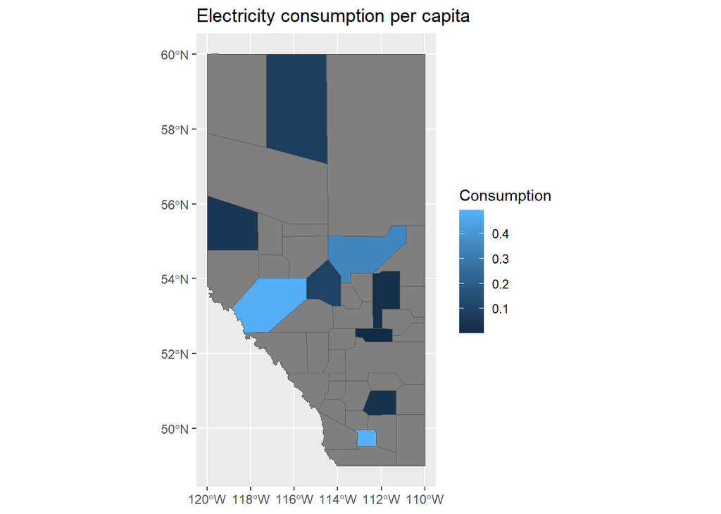

```r
ggplot() +
  geom_sf(data = shape_viz,
          aes(fill = ifelse(per_capita > 0, per_capita, NA))) +
  # scale_fill_viridis_c(na.value = "gray90") +
  labs(title = "Electricity consumption per capita",
       fill = "Consumption")
```

To make this better, let’s also add the labels (of each district) back to this plot.

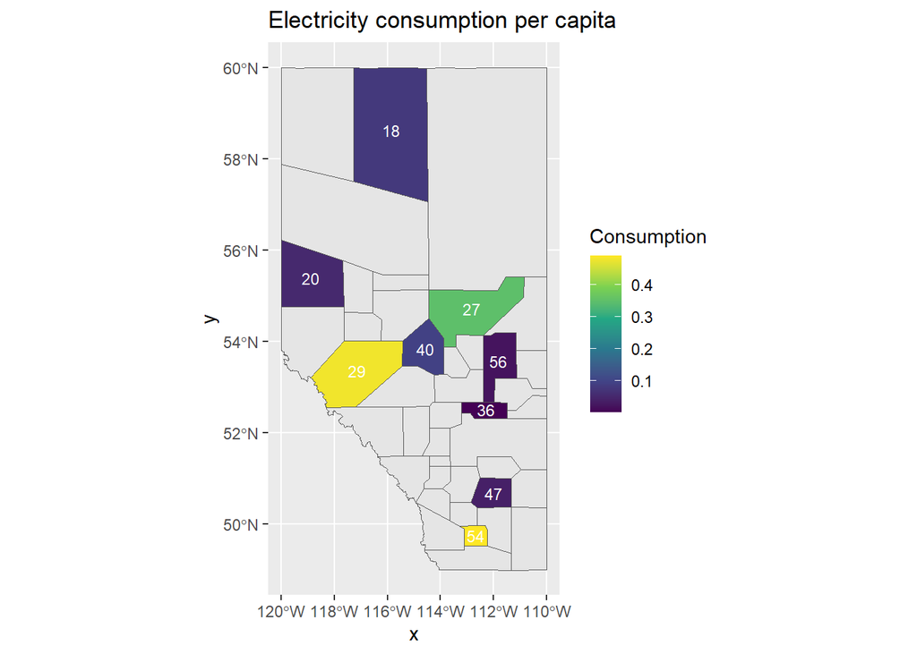

```r
ggplot() +
  geom_sf(data = shape_viz,
          aes(fill = ifelse(per_capita > 0, per_capita, NA))) +
  scale_fill_viridis_c(na.value = "gray90") +
  geom_sf_text(data = st_centroid(planning_areas_joined),
               aes(label = id_label),
               color = "white", size = 3) +
  labs(title = "Electricity consumption per capita",
       fill = "Consumption")
```